# Report: Data Analytics for Decision Making

Claudio Previte and Ana -Maria Casian

15 décembre, 2019

```r
library(here)
library(Hmisc)
library(dplyr)
library(DataExplorer)
library(ggplot2)
library(lattice)
library(inspectdf)
library(kableExtra)
library(explore)
library(DT)
library(dplyr)
library(Boruta)
library(corrr)
library(tidyverse)
library(caret)
library(randomForest)
library(funModeling)
library(gmodels)
```

# Executive summary

## Challenges

- describe the problem
- describe the dataset
- response variable

## Analysis

- classification model tested
- which ones are more adapted to the problem

## Results

- show results, accuracies
- recommendations and implementations

# General

- purpose of the course
- the benefit of Machine Learning in general

## Source of data

- where the data comes from
- quick description of the data

## Case description

- describe the problem
- benefit of Machine Learning in this special case

# Data processing

- explain the purpose of data cleaning
- why it is so important in data analytics

```r
bands <- read.csv2(file = here('bands3.csv'), sep = ';',na.strings = "?")
```

## Data visualization

The first task to analyze a dataset is to have a look at all the variables and their values.

```
## 'data.frame':    540 obs. of  40 variables:
##  $ date             : int  19910108 19910109 19910104 19910104 19910111 19910104 19910111 19910111 19910112 19910114 ...
##  $ cylinder_no      : Factor w/ 434 levels "1351","3","aa067",..: 297 338 22 249 176 255 332 401 202 153 ...
##  $ customer         : Factor w/ 83 levels "ABBEY","ABBEYPRESS",..: 75 75 61 58 55 58 67 67 61 18 ...
##  $ job_number       : int  25503 25503 47201 39039 37351 38039 35751 35751 47201 37000 ...
##  $ grain_screened   : Factor w/ 2 levels "NO","YES": 2 2 2 2 1 2 1 1 2 2 ...
##  $ ink_color        : Factor w/ 3 levels "key","KeY","KEY": 3 3 3 3 3 3 3 3 3 3 ...
##  $ proof_ink        : Factor w/ 2 levels "NO","YES": 2 2 2 2 2 2 2 2 2 2 ...
##  $ blade_mfg        : Factor w/ 2 levels "BENTON","UDDEHOLM": 1 1 1 1 1 1 1 1 1 1 ...
##  $ cylinder_division: Factor w/ 2 levels "gallatin","GALLATIN": 2 2 2 2 2 2 2 2 2 2 ...
##  $ paper_type       : Factor w/ 5 levels "coated","COATED",..: 5 5 5 5 5 5 2 2 5 5 ...
##  $ ink_type         : Factor w/ 6 levels "coated","COATED",..: 6 6 2 6 2 6 2 2 6 6 ...
##  $ direct_steam     : Factor w/ 3 levels "no","NO","YES": 2 2 2 2 2 2 2 2 2 2 ...
##  $ solvent_type     : Factor w/ 3 levels "LINE","NAPTHA",..: 1 1 1 1 1 1 1 1 3 1 ...
##  $ cylinder_type    : Factor w/ 4 levels "no","NO","yes",..: 4 4 4 4 4 4 4 4 4 4 ...
```

[output cut: 26 more lines]

As we were aware, this dataset needs a lot of cleaning before to be analyzed.

### Standardization of the dataset

As seen before, the data are not recorded in the same way for all the observations. Some observations are in upper cases and some are in lower cases. This can occur when many different people are in charge to record the data or depending the location where the observations comes from. This problem can lead to a bad data perception, so we decided to put all the values in upper cases.

Here is an overview of the dataset:

|  | date | cylinder_no | customer | job_number | grain_screened | ink_color | proof_ink | blade_mfg | cylinder_division | paper_type | ink_type | direct_steam | solvent_type | cylinder_type | press_type | press | unit_number | cylinder_size | location | plating_tank | proof_cut | viscosity | caliper | ink_temperature | humidity | roughness | blade_pressure | varnish_pct | press_speed | … |
| --- | --- | --- | --- | --- | --- | --- | --- | --- | --- | --- | --- | --- | --- | --- | --- | --- | --- | --- | --- | --- | --- | --- | --- | --- | --- | --- | --- | --- | --- | --- |
| 1 | 19910108 | X126 | TVGUIDE | 25503 | YES | KEY | YES | BENTON | GALLATIN | UNCOATED | UNCOATED | NO | LINE | YES | MOTTER94 | 821 | 2 | TABLOID | NORTHUS | 1911 | 55 | 46 | 0.2 | 17 | 78 | 0.75 | 20 | 13.1 | 1700 | … |
| 2 | 19910109 | X266 | TVGUIDE | 25503 | YES | KEY | YES | BENTON | GALLATIN | UNCOATED | UNCOATED | NO | LINE | YES | MOTTER94 | 821 | 2 | TABLOID | NORTHUS |  | 55 | 46 | 0.3 | 15 | 80 | 0.75 | 20 | 6.6 | 1900 | … |
| 3 | 19910104 | B7 | MODMAT | 47201 | YES | KEY | YES | BENTON | GALLATIN | UNCOATED | COATED | NO | LINE | YES | WOODHOE70 | 815 | 9 | CATALOG | NORTHUS |  | 62 | 40 | 0.433 | 16 | 80 |  | 30 | 6.5 | 1850 | … |
| 4 | 19910104 | T133 | MASSEY | 39039 | YES | KEY | YES | BENTON | GALLATIN | UNCOATED | UNCOATED | NO | LINE | YES | WOODHOE70 | 816 | 9 | CATALOG | NORTHUS | 1910 | 52 | 40 | 0.3 | 16 | 75 | 0.3125 | 30 | 5.6 | 1467 | … |
| 5 | 19910111 | J34 | KMART | 37351 | NO | KEY | YES | BENTON | GALLATIN | UNCOATED | COATED | NO | LINE | YES | WOODHOE70 | 816 | 2 | TABLOID |  | 1910 | 50 | 46 | 0.3 | 17 | 80 | 0.75 | 30 | 0 | 2100 | … |
| 6 | 19910104 | T218 | MASSEY | 38039 | YES | KEY | YES | BENTON | GALLATIN | UNCOATED | UNCOATED | NO | LINE | YES | WOODHOE70 | 816 | 2 | CATALOG | NORTHUS | 1910 | 50 | 40 | 0.267 | 16.8 | 76 | 0.4375 | 28 | 8.6 | 1467 | … |
| 7 | 19910111 | X249 | ROSES | 35751 | NO | KEY | YES | BENTON | GALLATIN | COATED | COATED | NO | LINE | YES | MOTTER94 | 827 | 2 | TABLOID | CANADIAN | 1911 | 50 | 46 | 0.3 | 16.5 | 75 | 0.75 | 30 | 0 | 2600 | … |
| 8 | 19910111 | X788 | ROSES | 35751 | NO | KEY | YES | BENTON | GALLATIN | COATED | COATED | NO | LINE | YES | MOTTER94 | 827 | 9 | TABLOID | CANADIAN | 1911 | 50 | 46 | 0.2 | 16.5 | 75 | 0.75 | 28 | 0 | 2600 | … |
| 9 | 19910112 | M372 | MODMAT | 47201 | YES | KEY | YES | BENTON | GALLATIN | UNCOATED | UNCOATED | NO | XYLOL | YES | ALBERT70 | 802 | 7 | CATALOG | NORTHUS | 1910 | 50 | 45 | 0.367 | 12 | 70 | 0.75 | 60 | 0 | 1650 | … |
| 10 | 19910114 | I320 | CHILDCRAFT | 37000 | YES | KEY | YES | BENTON | GALLATIN | UNCOATED | UNCOATED | NO | LINE | YES | WOODHOE70 | 815 | 2 | CATALOG | NORTHUS | 1911 | 65 | 43 | 0.333 | 16 | 75 | 1 | 32 | 22.7 | 1750 | … |

[output cut: 530 more lines]

Figure 2: Datatable

## Missing values

We will focus now on the missing values, which makes this dataset so special. In fact we observe a lot of missing value and we have to decide what to do with them.

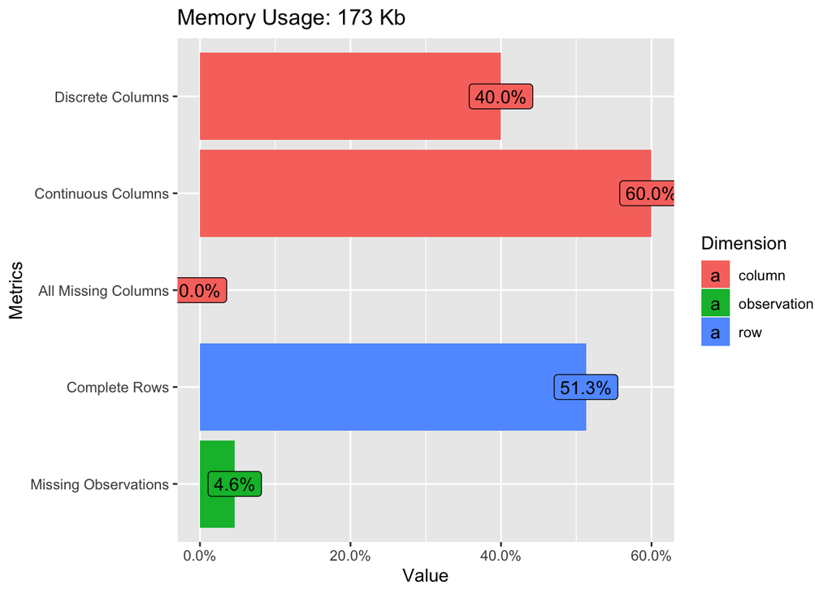

Figure 3

### Structure of the missing values

In this part we use the’aggr’ function Calculate or plot the amount of missing/imputed values in each variable and the amount of missing/imputed values in certain combinations of variables.

```r
library(VIM)
```

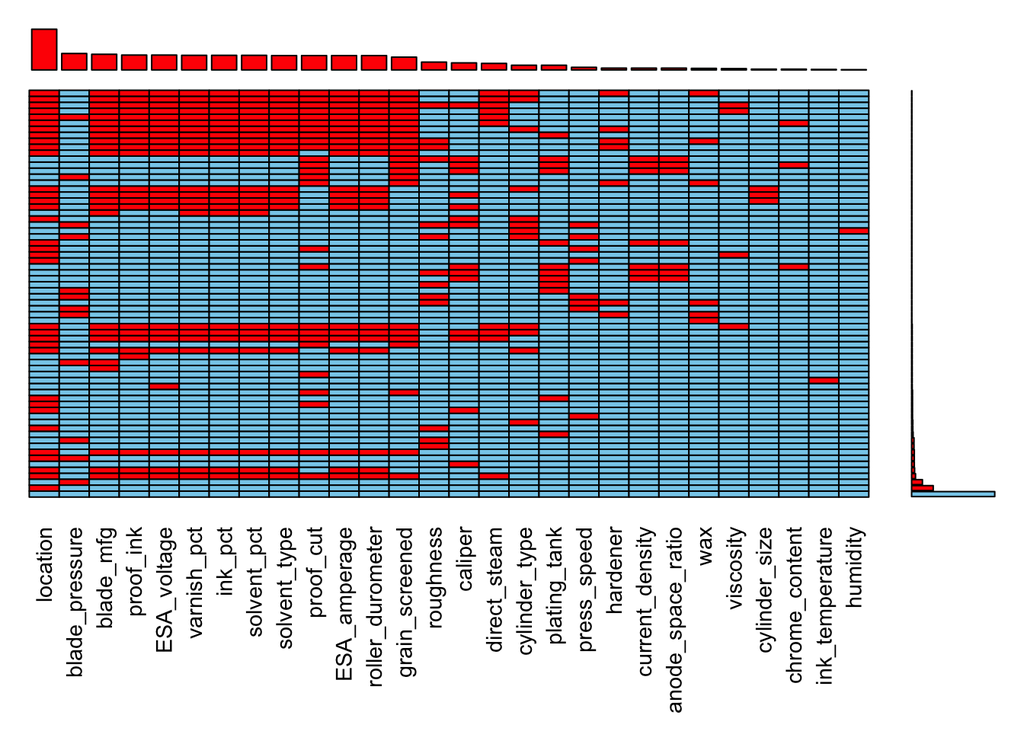

```
##
##  Variables sorted by number of missings:
##           Variable Count
##           location   156
##     blade_pressure    63
##          blade_mfg    60
##          proof_ink    57
##        ESA_voltage    57
##        varnish_pct    56
##            ink_pct    56
##        solvent_pct    56
##       solvent_type    55
##          proof_cut    55
##       ESA_amperage    55
##   roller_durometer    55
##     grain_screened    49
##          roughness    30
##            caliper    27
##       direct_steam    25
##      cylinder_type    18
##       plating_tank    18
##        press_speed    10
##           hardener     7
##    current_density     7
##  anode_space_ratio     7
##                wax     6
##          viscosity     5
##      cylinder_size     3
##     chrome_content     3
##    ink_temperature     2
##           humidity     1
```

```r
aggr(bands[, which(sapply(bands, function(x)all(any(is.na(x)))) == TRUE)], sortVar=TRUE, cex.lab=0.8, cex.axis=0.9,  numbers = TRUE, combined = TRUE,  oma = c(8,1,1,1))
```

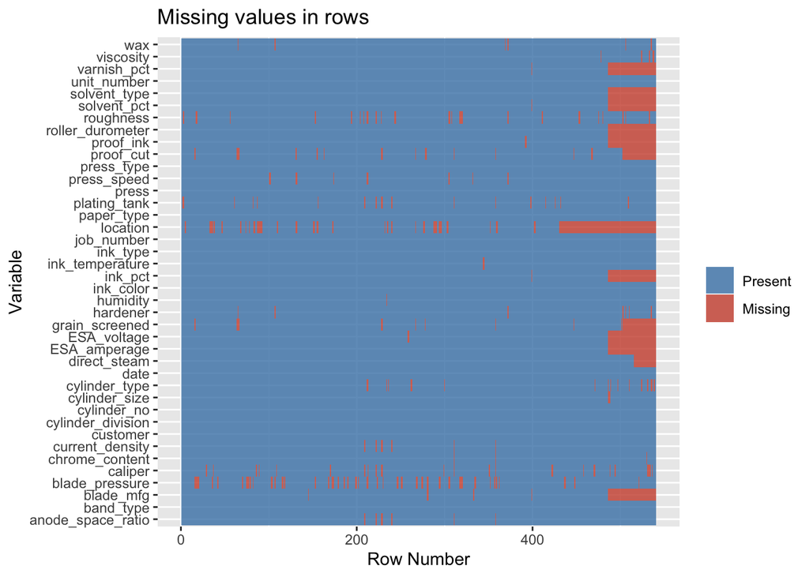

```r
row.plot <- bands %>%
  mutate(id = row_number()) %>%
  gather(-id, key = "key", value = "val") %>%
  mutate(isna = is.na(val)) %>%
  ggplot(aes(key, id, fill = isna)) +
    geom_raster(alpha=0.8) +
    scale_fill_manual(name = "",
        values = c('steelblue', 'tomato3'),
        labels = c("Present", "Missing")) +
    labs(x = "Variable",
           y = "Row Number", title = "Missing values in rows") +
    coord_flip()
row.plot
```

EDA

```r
bands %>%
  introduce() %>%
  t() %>%
  kable() %>%
  kable_styling(
    bootstrap_options = c("striped", "hover", "condensed", "bordered"),
    full_width = F,
    position = "center"
  ) %>%
  footnote(symbol = strwrap("Short description of the data"))
```

| rows | 540 |
| --- | --- |
| columns | 40 |
| discrete_columns | 16 |
| continuous_columns | 24 |
| all_missing_columns | 0 |
| total_missing_values | 999 |
| complete_rows | 277 |
| total_observations | 21600 |
| memory_usage | 177192 |

* Short description of the data

```r
summary(bands) %>%
  kable()
```

|  | date | cylinder_no | customer | job_number | grain_screened | ink_color | proof_ink | blade_mfg | cylinder_division | paper_type | ink_type | direct_steam | solvent_type | cylinder_type | press_type | press | unit_number | cylinder_size | location | plating_tank | proof_cut | viscosity | caliper | ink_temperature | humidity | roughness | blade_pressure | varnish_pct | press_speed | … |
| --- | --- | --- | --- | --- | --- | --- | --- | --- | --- | --- | --- | --- | --- | --- | --- | --- | --- | --- | --- | --- | --- | --- | --- | --- | --- | --- | --- | --- | --- | --- |
|  | Min. :19900330 | M254 : 5 | KMART : 67 | Min. :23040 | NO :281 | KEY:540 | NO : 22 | BENTON :479 | GALLATIN:540 | COATED :223 | COATED :291 | NO :513 | LINE :468 | NO :136 | ALBERT70 : 78 | Min. :802.0 | Min. : 1.000 | CATALOG:178 | CANADIAN :159 | Min. :1910 | Min. :25.00 | Min. :35.00 | Min. :0.1330 | Min. :11.20 | Min. : 57.00 | Min. :0.05625 | Min. :16.0 | Min. : 0.000 | Min. : 0 | … |
|  | 1st Qu.:19900909 | X129 : 5 | MODMAT : 64 | 1st Qu.:34585 | YES :210 | NA | YES :461 | UDDEHOLM: 1 | NA | SUPER : 23 | COVER : 18 | YES : 2 | NAPTHA: 2 | YES :386 | MOTTER70 : 48 | 1st Qu.:815.0 | 1st Qu.: 2.000 | SPIEGEL: 60 | MIDEUROPEAN : 15 | 1st Qu.:1910 | 1st Qu.:40.00 | 1st Qu.:43.00 | 1st Qu.:0.2000 | 1st Qu.:14.60 | 1st Qu.: 73.00 | 1st Qu.:0.62500 | 1st Qu.:25.0 | 1st Qu.: 0.000 | 1st Qu.:1600 | … |
|  | Median :19910117 | F601 : 4 | TARGET : 41 | Median :36062 | NA’s: 49 | NA | NA’s: 57 | NA’s : 60 | NA | UNCOATED:294 | UNCOATED:231 | NA’s: 25 | XYLOL : 15 | NA’s: 18 | MOTTER94 :238 | Median :816.0 | Median : 2.000 | TABLOID:299 | NORTHUS :189 | Median :1910 | Median :45.00 | Median :50.00 | Median :0.2670 | Median :15.20 | Median : 78.00 | Median :0.75000 | Median :30.0 | Median : 3.400 | Median :1800 | … |
|  | Mean :19907801 | R15 : 4 | TVGUIDE: 38 | Mean :37288 | NA | NA | NA | NA | NA | NA | NA | NA | NA’s : 55 | NA | WOODHOE70:176 | Mean :817.7 | Mean : 4.878 | NA’s : 3 | SCANDANAVIAN: 13 | Mean :1910 | Mean :45.04 | Mean :50.94 | Mean :0.2757 | Mean :15.36 | Mean : 78.55 | Mean :0.72451 | Mean :30.9 | Mean : 5.781 | Mean :1823 | … |
|  | 3rd Qu.:19910604 | R6 : 4 | WARDS : 33 | 3rd Qu.:37528 | NA | NA | NA | NA | NA | NA | NA | NA | NA | NA | NA | 3rd Qu.:824.0 | 3rd Qu.: 9.000 | NA | SOUTHUS : 8 | 3rd Qu.:1911 | 3rd Qu.:50.00 | 3rd Qu.:56.00 | 3rd Qu.:0.3000 | 3rd Qu.:16.00 | 3rd Qu.: 82.00 | 3rd Qu.:0.81250 | 3rd Qu.:33.0 | 3rd Qu.:10.425 | 3rd Qu.:2042 | … |
|  | Max. :19941010 | F670 : 3 | TOYSRUS: 26 | Max. :88231 | NA | NA | NA | NA | NA | NA | NA | NA | NA | NA | NA | Max. :828.0 | Max. :10.000 | NA | NA’s :156 | Max. :1911 | Max. :72.50 | Max. :72.00 | Max. :0.5330 | Max. :24.50 | Max. :105.00 | Max. :1.25000 | Max. :70.0 | Max. :35.800 | Max. :2600 | … |
|  | NA | (Other):515 | (Other):271 | NA | NA | NA | NA | NA | NA | NA | NA | NA | NA | NA | NA | NA | NA | NA | NA | NA’s :18 | NA’s :55 | NA’s :5 | NA’s :27 | NA’s :2 | NA’s :1 | NA’s :30 | NA’s :63 | NA’s :56 | NA’s :10 | … |

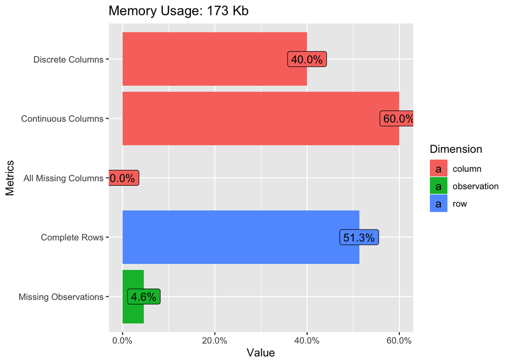

```r
plot_intro(bands)
```

```r
bands %>%
  explore::describe() %>%
  kable() %>%
  kable_styling(bootstrap_options = c("striped", "hover","condensed","bordered"),full_width = F, position = "center")
```

| variable | type | na | na_pct | unique | min | mean | max |
| --- | --- | --- | --- | --- | --- | --- | --- |
| date | int | 0 | 0.0 | 296 | 19900330.00 | 19907800.77 | 19941010.00 |
| cylinder_no | fct | 0 | 0.0 | 429 | NA | NA | NA |
| customer | fct | 0 | 0.0 | 71 | NA | NA | NA |
| job_number | int | 0 | 0.0 | 262 | 23040.00 | 37287.53 | 88231.00 |
| grain_screened | fct | 49 | 9.1 | 3 | NA | NA | NA |
| ink_color | fct | 0 | 0.0 | 1 | NA | NA | NA |
| proof_ink | fct | 57 | 10.6 | 3 | NA | NA | NA |
| blade_mfg | fct | 60 | 11.1 | 3 | NA | NA | NA |
| cylinder_division | fct | 0 | 0.0 | 1 | NA | NA | NA |
| paper_type | fct | 0 | 0.0 | 3 | NA | NA | NA |
| ink_type | fct | 0 | 0.0 | 3 | NA | NA | NA |
| direct_steam | fct | 25 | 4.6 | 3 | NA | NA | NA |
| solvent_type | fct | 55 | 10.2 | 4 | NA | NA | NA |
| cylinder_type | fct | 18 | 3.3 | 3 | NA | NA | NA |
| press_type | fct | 0 | 0.0 | 4 | NA | NA | NA |
| press | int | 0 | 0.0 | 8 | 802.00 | 817.68 | 828.00 |
| unit_number | int | 0 | 0.0 | 7 | 1.00 | 4.88 | 10.00 |
| cylinder_size | fct | 3 | 0.6 | 4 | NA | NA | NA |
| location | fct | 156 | 28.9 | 6 | NA | NA | NA |
| plating_tank | int | 18 | 3.3 | 3 | 1910.00 | 1910.36 | 1911.00 |
| proof_cut | dbl | 55 | 10.2 | 28 | 25.00 | 45.04 | 72.50 |
| viscosity | dbl | 5 | 0.9 | 38 | 35.00 | 50.94 | 72.00 |
| caliper | dbl | 27 | 5.0 | 18 | 0.13 | 0.28 | 0.53 |
| ink_temperature | dbl | 2 | 0.4 | 66 | 11.20 | 15.36 | 24.50 |
| humidity | dbl | 1 | 0.2 | 43 | 57.00 | 78.55 | 105.00 |
| roughness | dbl | 30 | 5.6 | 19 | 0.06 | 0.72 | 1.25 |
| blade_pressure | dbl | 63 | 11.7 | 37 | 16.00 | 30.90 | 70.00 |
| varnish_pct | dbl | 56 | 10.4 | 123 | 0.00 | 5.78 | 35.80 |
| press_speed | dbl | 10 | 1.9 | 84 | 0.00 | 1823.44 | 2600.00 |
| ink_pct | dbl | 56 | 10.4 | 82 | 41.00 | 55.64 | 76.90 |
| solvent_pct | dbl | 56 | 10.4 | 116 | 22.00 | 38.57 | 53.40 |
| ESA_voltage | dbl | 57 | 10.6 | 18 | 0.00 | 1.32 | 16.00 |
| ESA_amperage | dbl | 55 | 10.2 | 5 | 0.00 | 0.04 | 6.00 |
| wax | dbl | 6 | 1.1 | 31 | 0.00 | 2.40 | 3.10 |
| hardener | dbl | 7 | 1.3 | 30 | 0.00 | 0.99 | 3.00 |
| roller_durometer | dbl | 55 | 10.2 | 13 | 28.00 | 34.78 | 60.00 |
| current_density | dbl | 7 | 1.3 | 8 | 30.00 | 39.06 | 45.00 |
| anode_space_ratio | dbl | 7 | 1.3 | 81 | 83.33 | 103.04 | 117.86 |
| chrome_content | dbl | 3 | 0.6 | 4 | 90.00 | 99.59 | 100.00 |
| band_type | fct | 0 | 0.0 | 2 | NA | NA | NA |

```r
#Delete the last rows that have consecutive missing data
bands <- bands[-c(486:540),]

# replace missing values of "location variable" with value "Undefined"
bands$location = as.character(bands$location)
bands$location[is.na(bands$location)] <- "UNDEFINED"
bands$location = as.factor(bands$location)

# Delete variables that are not needed
bands <-
  bands[, which(
    !names(bands) %in% c(
      "date",
      "ink_color",
      "customer",
      'cylinder_division',
      'cylinder_no',
      'job_number'

    )
  )]
```

```r
# replace missing values with knn
# we have to decide if we want to reèlace only factor or all variables with this method...
library(DMwR)
bands <- knnImputation(bands, k=10)

# check missing value
anyNA(bands)
```

```
## [1] FALSE
```